# **Project 1 ‘Part 3-Association’**

Sachin Samal (ECU ID 250008)

Oct 21, 2021

### **DATA MINING WITH R**

Here in this part of project, I have decided to work on the association with my previous dataset from [**Project 1**](https://rpubs.com/sacsam005/808877) and [**Project 2**](https://rpubs.com/sacsam005/813688). For this project, I have pulled the data from [**English Premier League Results**](https://www.premierleague.com/results.).

### **WHAT IS ASSOCIATION?**

**It is the method to discover relationships between seemingly independent relational databases or other data repositories. It aims to observe frequently occurring patterns, correlations, or associations from datasets found in various kinds of databases such as relational databases, transactional databases, and other forms of repositories.**

#### **LETS START OUT ASSOCIATION MINING…**

#### **LOADING MY EXCEL DATA INTO R ENVIRONMENT**

```r
library(readxl)
Results <- read_excel("Results.xlsx")
str(Results)
```

```
## tibble [380 × 6] (S3: tbl_df/tbl/data.frame)
##  $ Home_team: chr [1:380] "Arsenal" "Watford" "Chelsea" "Crystal Palace" ...
##  $ Away_team: chr [1:380] "Leicester City" "Liverpool" "Burnley" "Huddersfield Town" ...
##  $ Home_goal: num [1:380] 4 3 2 0 1 0 1 0 0 4 ...
##  $ Away_goal: num [1:380] 3 3 3 3 0 0 0 2 2 0 ...
##  $ Result   : chr [1:380] "H" "D" "A" "A" ...
##  $ Season   : chr [1:380] "2017-2018" "2017-2018" "2017-2018" "2017-2018" ...
```

```r
summary(Results$Home_goal)
```

```
##    Min. 1st Qu.  Median    Mean 3rd Qu.    Max.
##   0.000   1.000   1.000   1.532   2.000   7.000
```

#### **ASSOCIATION MINING WITH R**

```r
library(arules)
```

```r
library(arulesViz)
```

**Here, I have added some new libraries. Now, I need to convert the data for association analysis.**

**Now, I need to look at the columns to see if I can convert them into factors (or Boolean values) for analysis. This is because if not, I have to use different methods like *“Kruskal Wallis test” or “Chi-square test”* based on the requirement of my dataset.**

```r
colnames(Results)[c(1,2,3,4,5)]
```

```
## [1] "Home_team" "Away_team" "Home_goal" "Away_goal" "Result"
```

**I don’t find anything that needs much attention. So , I will continue with the process as it needs.**

#### **CREATE TRANSACTION**

**I will let R do the default discretization to the rest of the data. This is because I could not come up with better cutoffs for what is left in the dataset.**

```r
library(ggplot2)
trans <- transactions(Results)
```

```
## Warning: Column(s) 1, 2, 3, 4, 5, 6 not logical or factor. Applying default
## discretization (see '? discretizeDF').
```

```
## Warning in discretize(x = c(3, 3, 3, 3, 0, 0, 0, 2, 2, 0, 4, 2, 1, 0, 0, : The calculated breaks are: 0, 0, 1, 6
##   Only unique breaks are used reducing the number of intervals. Look at ? discretize for details.
```

**The conversion gives a warning because only discrete features (factor and logical) can be directly translated into items. Continuous features need to be discretized first.**

```r
summary(Results[5])
```

```
##     Result
##  Length:380
##  Class :character
##  Mode  :character
```

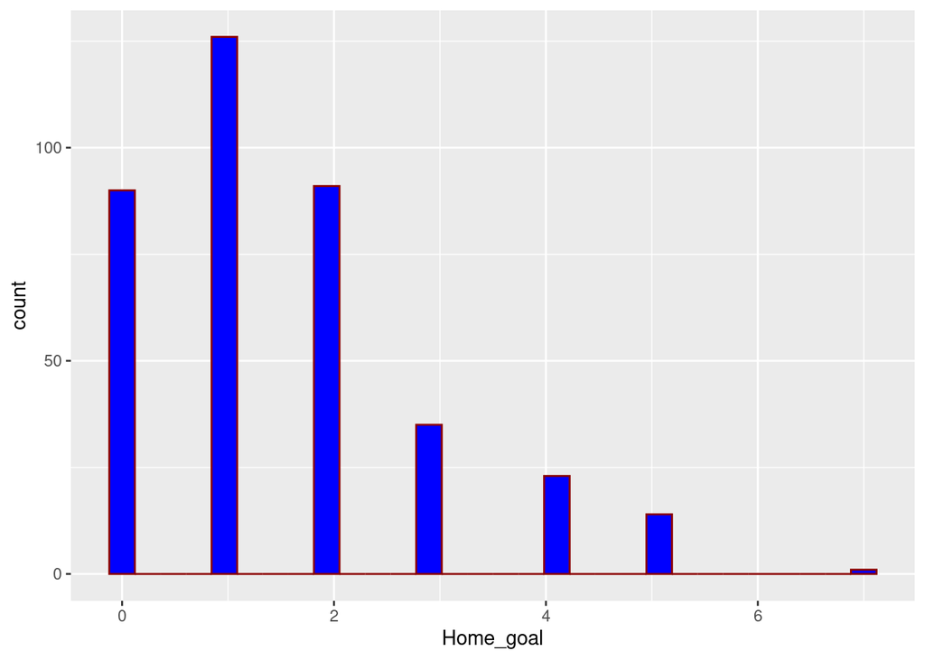

```r
ggplot(Results, aes(Home_goal)) + geom_histogram(fill='blue', color='darkred')
```

```r
table(Results$Home_goal)
```

```
##
##   0   1   2   3   4   5   7
##  90 126  91  35  23  14   1
```

```r
library(dplyr)
```

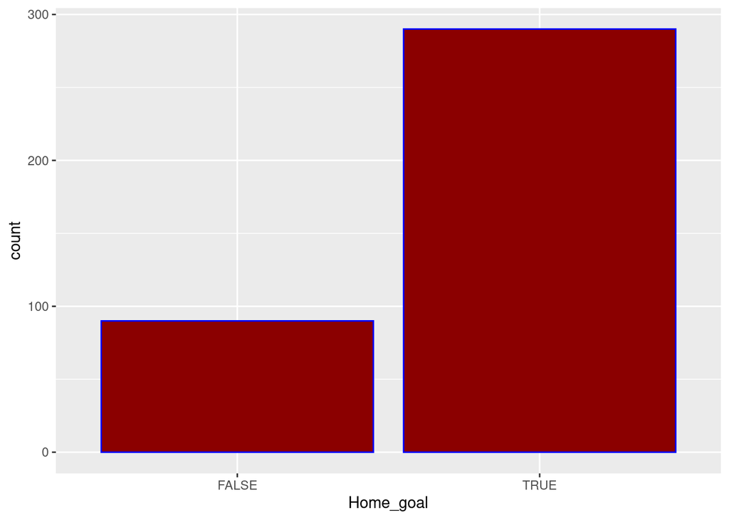

```r
Results <- Results %>% mutate(Home_goal = Home_goal > 0)
ggplot(Results, aes(Home_goal)) + geom_bar(fill='darkred', color='blue')
```

```r
table(Results$Home_goal)
```

```
##
## FALSE  TRUE
##    90   290
```

#### **INSPECT TRANSACTION**

**Now, Lets run the transaction and see how the data has cleaned.**

```r
summary(trans)
```

```
## transactions as itemMatrix in sparse format with
##  380 rows (elements/itemsets/transactions) and
##  49 columns (items) and a density of 0.122449
##
## most frequent items:
## Season=2017-2018  Away_goal=[1,6]         Result=H  Home_goal=[2,7]
##              380              244              173              164
##  Away_goal=[0,1)          (Other)
##              136             1183
##
## element (itemset/transaction) length distribution:
## sizes
##   6
## 380
##
##    Min. 1st Qu.  Median    Mean 3rd Qu.    Max.
##       6       6       6       6       6       6
##
## includes extended item information - examples:
##                               labels variables                   levels
## 1          Home_team=AFC Bournemouth Home_team          AFC Bournemouth
## 2                  Home_team=Arsenal Home_team                  Arsenal
## 3 Home_team=Brighton and Hove Albion Home_team Brighton and Hove Albion
##
## includes extended transaction information - examples:
##   transactionID
## 1             1
## 2             2
## 3             3
```

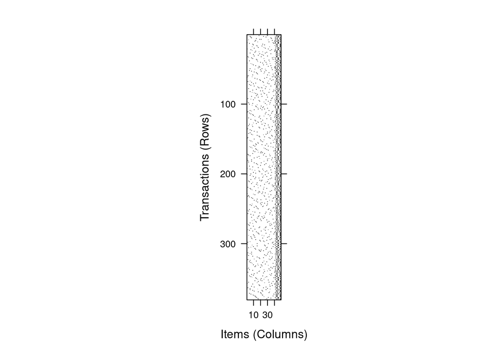

```r
library(colorRamps)
#plotting image for transaction
image(trans, fill="red")
```

#### **THE MOST FREQUENT ITEMS ON THE DATASET**

```r
frequentItems <- apriori(trans, parameter=list(target = "frequent"))
```

```
## Apriori
##
## Parameter specification:
##  confidence minval smax arem  aval originalSupport maxtime support minlen
##          NA    0.1    1 none FALSE            TRUE       5     0.1      1
##  maxlen            target  ext
##      10 frequent itemsets TRUE
##
## Algorithmic control:
##  filter tree heap memopt load sort verbose
##     0.1 TRUE TRUE  FALSE TRUE    2    TRUE
##
## Absolute minimum support count: 38
##
## set item appearances ...[0 item(s)] done [0.00s].
## set transactions ...[49 item(s), 380 transaction(s)] done [0.00s].
## sorting and recoding items ... [9 item(s)] done [0.00s].
## creating transaction tree ... done [0.00s].
## checking subsets of size 1 2 3 4 done [0.00s].
## sorting transactions ... done [0.00s].
## writing ... [53 set(s)] done [0.00s].
## creating S4 object  ... done [0.00s].
```

```r
inspect(frequentItems)
```

```
##      items                support transIdenticalToItemsets count
## [1]  {Home_goal=[0,1)}  0.2368421                0.0000000    90
## [2]  {Result=D}         0.2605263                0.0000000    99
## [3]  {Result=A}         0.2842105                0.0000000   108
## [4]  {Home_goal=[1,2)}  0.3315789                0.0000000   126
## [5]  {Away_goal=[0,1)}  0.3578947                0.0000000   136
## [6]  {Home_goal=[2,7]}  0.4315789                0.0000000   164
## [7]  {Result=H}         0.4552632                0.0000000   173
## [8]  {Away_goal=[1,6]}  0.6421053                0.0000000   244
## [9]  {Season=2017-2018} 1.0000000                0.0000000   380
## [10] {Home_goal=[0,1),
##       Result=A}         0.1526316                0.0000000    58
## [11] {Home_goal=[0,1),
##       Away_goal=[1,6]}  0.1526316                0.0000000    58
## [12] {Home_goal=[0,1),
##       Season=2017-2018} 0.2368421                0.0000000    90
## [13] {Home_goal=[1,2),
##       Result=D}         0.1184211                0.0000000    45
## [14] {Away_goal=[1,6],
##       Result=D}         0.1763158                0.0000000    67
## [15] {Result=D,
##       Season=2017-2018} 0.2605263                0.0000000    99
## [16] {Away_goal=[1,6],
##       Result=A}         0.2842105                0.0000000   108
## [17] {Result=A,
##       Season=2017-2018} 0.2842105                0.0000000   108
## [18] {Home_goal=[1,2),
##       Away_goal=[0,1)}  0.1157895                0.0000000    44
## [19] {Home_goal=[1,2),
##       Result=H}         0.1157895                0.0000000    44
## [20] {Home_goal=[1,2),
##       Away_goal=[1,6]}  0.2157895                0.0000000    82
## [21] {Home_goal=[1,2),
##       Season=2017-2018} 0.3315789                0.0000000   126
## [22] {Home_goal=[2,7],
##       Away_goal=[0,1)}  0.1578947                0.0000000    60
## [23] {Away_goal=[0,1),
##       Result=H}         0.2736842                0.0000000   104
## [24] {Away_goal=[0,1),
##       Season=2017-2018} 0.3578947                0.0000000   136
```

[output cut: 71 more lines]

```
##       Away_goal=[1,6],
##       Result=D,
##       Season=2017-2018} 0.1184211                0.1184211    45
## [51] {Home_goal=[1,2),
##       Away_goal=[0,1),
##       Result=H,
##       Season=2017-2018} 0.1157895                0.1157895    44
## [52] {Home_goal=[2,7],
##       Away_goal=[0,1),
##       Result=H,
##       Season=2017-2018} 0.1578947                0.1578947    60
## [53] {Home_goal=[2,7],
##       Away_goal=[1,6],
##       Result=H,
##       Season=2017-2018} 0.1815789                0.1815789    69
```

```r
#calculating the frequent items
frequentItems
```

```
## set of 53 itemsets
```

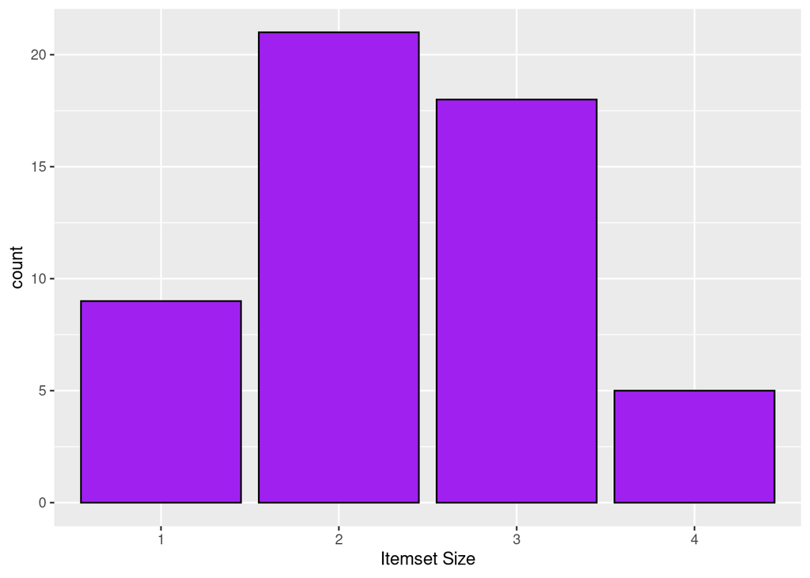

```r
ggplot(tibble(`Itemset Size` = factor(size(frequentItems))), aes(`Itemset Size`)) + geom_bar(fill = "purple", color = "black")
```

#### **Apriori WITH R - GENERATING RULES**

**We will generate parameters support and confidence for rule mining and lift for interestingness evaluation.**

**Support indicates how frequently the itemset appears in the dataset.**

**Confidence is the proportion of the true positive of the rule.**

**Lets find out the rules using the apriori algorithm.**

```r
library(arules)
#association rules.
rules <- apriori(Results,
                 parameter = list(supp = 0.05, conf = 0.9,
                                  target = "rules"))
```

```
## Apriori
##
## Parameter specification:
##  confidence minval smax arem  aval originalSupport maxtime support minlen
##         0.9    0.1    1 none FALSE            TRUE       5    0.05      1
##  maxlen target  ext
##      10  rules TRUE
##
## Algorithmic control:
##  filter tree heap memopt load sort verbose
##     0.1 TRUE TRUE  FALSE TRUE    2    TRUE
##
## Absolute minimum support count: 19
##
## set item appearances ...[0 item(s)] done [0.00s].
## set transactions ...[47 item(s), 380 transaction(s)] done [0.00s].
## sorting and recoding items ... [47 item(s)] done [0.00s].
## creating transaction tree ... done [0.00s].
## checking subsets of size 1 2 3 4 done [0.00s].
## writing ... [77 rule(s)] done [0.00s].
## creating S4 object  ... done [0.00s].
```

**minval** is the minimum value of the support an itemset should satisfy to be a part of a rule.

**smax** is the maximum support value for an itemset.

**arem** is an Additional Rule Evaluation Parameter (similar to lift).

**aval** is a logical indicating whether to return the additional rule evaluation measure selected with arem.

**originalSupport** is the traditional support value that consider both LHS and RHS items for calculating support. If you want to use only the LHS items for the calculation then you need to set this to FALSE.

**maxtime** is the maximum amount of time allowed to check for subsets.

**minlen** is the minimum number of items required in the rule.

**maxlen** is the maximum number of items that can be present in the rule.

```r
#length
length(rules)
```

```
## [1] 77
```

```r
#sorting the rules and printing it
rules.sorted <-sort(rules, by="lift")
inspect(rules.sorted)
```

```
##      lhs                                     rhs                   support confidence   coverage     lift count
## [1]  {Home_goal,
##       Away_goal=[0,1)}                    => {Result=H}         0.27368421          1 0.27368421 2.196532   104
## [2]  {Home_goal,
##       Away_goal=[0,1),
##       Season=2017-2018}                   => {Result=H}         0.27368421          1 0.27368421 2.196532   104
## [3]  {Result=A}                           => {Away_goal=[1,6]}  0.28421053          1 0.28421053 1.557377   108
## [4]  {Home_goal,
##       Result=D}                           => {Away_goal=[1,6]}  0.17631579          1 0.17631579 1.557377    67
## [5]  {Home_goal,
##       Result=A}                           => {Away_goal=[1,6]}  0.13157895          1 0.13157895 1.557377    50
## [6]  {Result=A,
##       Season=2017-2018}                   => {Away_goal=[1,6]}  0.28421053          1 0.28421053 1.557377   108
## [7]  {Home_goal,
##       Result=D,
##       Season=2017-2018}                   => {Away_goal=[1,6]}  0.17631579          1 0.17631579 1.557377    67
## [8]  {Home_goal,
##       Result=A,
##       Season=2017-2018}                   => {Away_goal=[1,6]}  0.13157895          1 0.13157895 1.557377    50
## [9]  {Result=H}                           => {Home_goal}        0.45526316          1 0.45526316 1.310345   173
## [10] {Away_goal=[1,6],
##       Result=D}                           => {Home_goal}        0.17631579          1 0.17631579 1.310345    67
## [11] {Away_goal=[0,1),
##       Result=H}                           => {Home_goal}        0.27368421          1 0.27368421 1.310345   104
## [12] {Away_goal=[1,6],
##       Result=H}                           => {Home_goal}        0.18157895          1 0.18157895 1.310345    69
## [13] {Result=H,
##       Season=2017-2018}                   => {Home_goal}        0.45526316          1 0.45526316 1.310345   173
## [14] {Away_goal=[1,6],
##       Result=D,
##       Season=2017-2018}                   => {Home_goal}        0.17631579          1 0.17631579 1.310345    67
## [15] {Away_goal=[0,1),
##       Result=H,
##       Season=2017-2018}                   => {Home_goal}        0.27368421          1 0.27368421 1.310345   104
## [16] {Away_goal=[1,6],
##       Result=H,
##       Season=2017-2018}                   => {Home_goal}        0.18157895          1 0.18157895 1.310345    69
## [17] {}                                   => {Season=2017-2018} 1.00000000          1 1.00000000 1.000000   380
## [18] {Away_team=Manchester City}          => {Season=2017-2018} 0.05000000          1 0.05000000 1.000000    19
## [19] {Home_team=Huddersfield Town}        => {Season=2017-2018} 0.05000000          1 0.05000000 1.000000    19
```

[output cut: 61 more lines]

```
##       Result=H}                           => {Season=2017-2018} 0.45526316          1 0.45526316 1.000000   173
## [73] {Home_goal,
##       Away_goal=[1,6]}                    => {Season=2017-2018} 0.48947368          1 0.48947368 1.000000   186
## [74] {Home_goal,
##       Away_goal=[1,6],
##       Result=D}                           => {Season=2017-2018} 0.17631579          1 0.17631579 1.000000    67
## [75] {Home_goal,
##       Away_goal=[1,6],
##       Result=A}                           => {Season=2017-2018} 0.13157895          1 0.13157895 1.000000    50
## [76] {Home_goal,
##       Away_goal=[0,1),
##       Result=H}                           => {Season=2017-2018} 0.27368421          1 0.27368421 1.000000   104
## [77] {Home_goal,
##       Away_goal=[1,6],
##       Result=H}                           => {Season=2017-2018} 0.18157895          1 0.18157895 1.000000    69
```

```r
summary(rules)
```

```
## set of 77 rules
##
## rule length distribution (lhs + rhs):sizes
##  1  2  3  4
##  1 48 18 10
##
##    Min. 1st Qu.  Median    Mean 3rd Qu.    Max.
##   1.000   2.000   2.000   2.481   3.000   4.000
##
## summary of quality measures:
##     support         confidence    coverage           lift
##  Min.   :0.0500   Min.   :1    Min.   :0.0500   Min.   :1.000
##  1st Qu.:0.0500   1st Qu.:1    1st Qu.:0.0500   1st Qu.:1.000
##  Median :0.0500   Median :1    Median :0.0500   Median :1.000
##  Mean   :0.1683   Mean   :1    Mean   :0.1683   Mean   :1.107
##  3rd Qu.:0.2737   3rd Qu.:1    3rd Qu.:0.2737   3rd Qu.:1.000
##  Max.   :1.0000   Max.   :1    Max.   :1.0000   Max.   :2.197
##      count
##  Min.   : 19.00
##  1st Qu.: 19.00
##  Median : 19.00
##  Mean   : 63.95
##  3rd Qu.:104.00
##  Max.   :380.00
##
## mining info:
##     data ntransactions support confidence
##  Results           380    0.05        0.9
```

```
## To reduce overplotting, jitter is added! Use jitter = 0 to prevent jitter.
```

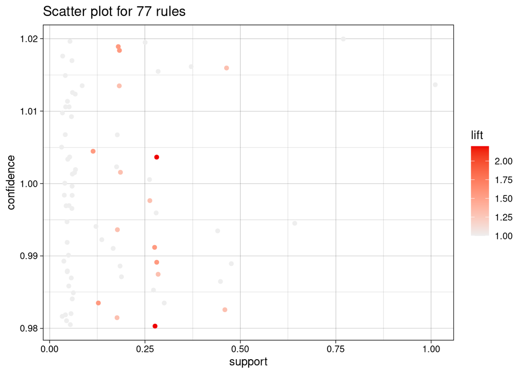

```r
#plot rules.sorted
plot(rules.sorted)
```

```r
plot(rules, method = "graph", measure = "lift", shading = "confidence", engine = "htmlwidget")
```

[interactive chart not shown]

```r
rules <- apriori(trans, parameter = list(support = 0.05, confidence = 0.9))
```

```
## Apriori
##
## Parameter specification:
##  confidence minval smax arem  aval originalSupport maxtime support minlen
##         0.9    0.1    1 none FALSE            TRUE       5    0.05      1
##  maxlen target  ext
##      10  rules TRUE
##
## Algorithmic control:
##  filter tree heap memopt load sort verbose
##     0.1 TRUE TRUE  FALSE TRUE    2    TRUE
##
## Absolute minimum support count: 19
##
## set item appearances ...[0 item(s)] done [0.00s].
## set transactions ...[49 item(s), 380 transaction(s)] done [0.00s].
## sorting and recoding items ... [49 item(s)] done [0.00s].
## creating transaction tree ... done [0.00s].
## checking subsets of size 1 2 3 4 done [0.00s].
## writing ... [101 rule(s)] done [0.00s].
## creating S4 object  ... done [0.00s].
```

### **Lets inspect the top three rules sorted by confidence.**

```r
inspect(head(sort(rules, by = "confidence"), 3))
```

```
##     lhs                              rhs                support confidence
## [1] {}                            => {Season=2017-2018} 1.00    1
## [2] {Home_team=Arsenal}           => {Season=2017-2018} 0.05    1
## [3] {Away_team=Tottenham Hotspur} => {Season=2017-2018} 0.05    1
##     coverage lift count
## [1] 1.00     1    380
## [2] 0.05     1     19
## [3] 0.05     1     19
```

### **VISUALIZING ASSOCIATION RULES**

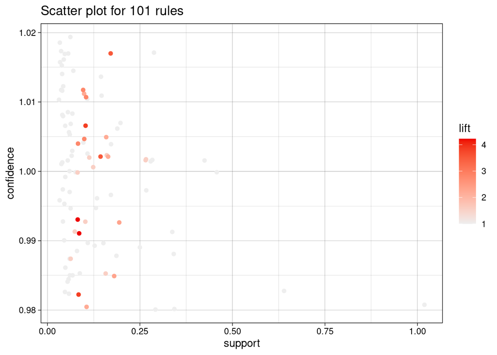

```r
plot(rules,jitter = 1)
```

```
## To reduce overplotting, jitter is added! Use jitter = 0 to prevent jitter.
```

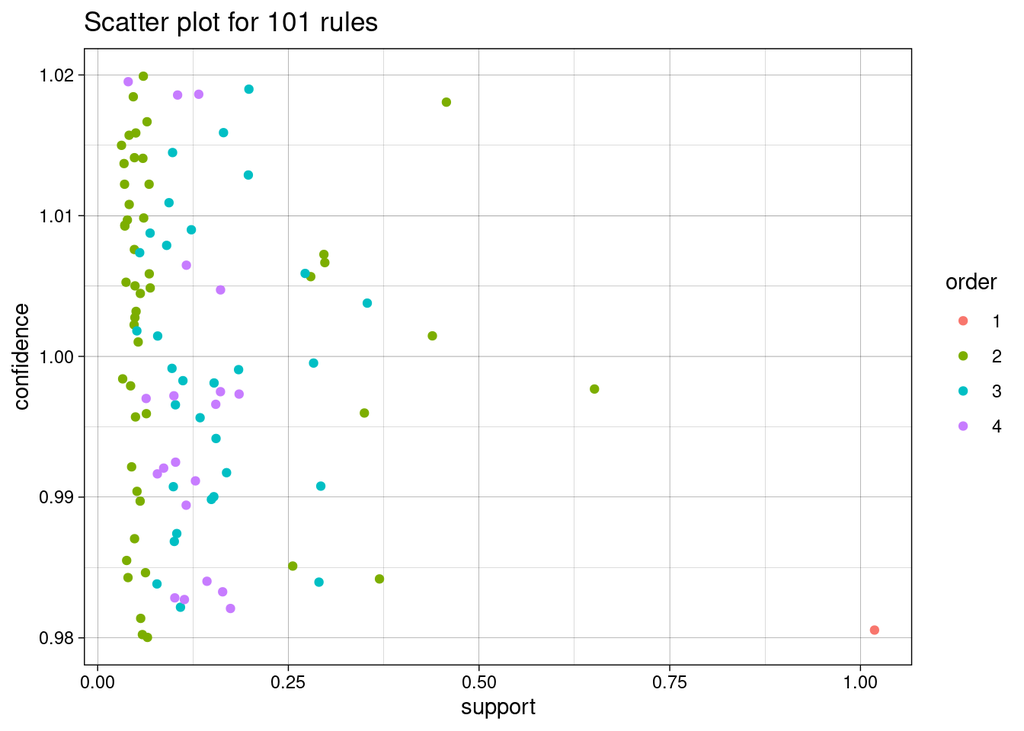

```r
plot(rules,  shading = "order", color=c("darkred", "purple"))
```

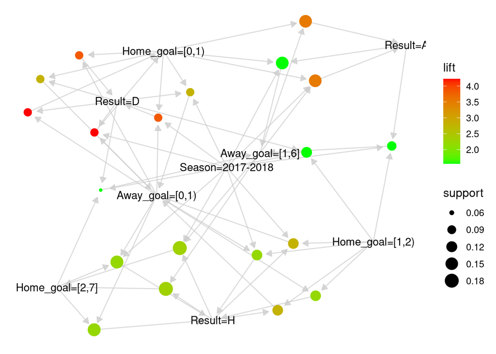

```r
#Graph plot for items
plot(rules, method="graph", max=20, control=list(verbose = FALSE), colors=c("red", "green"))
```

```
## Itemsets in Antecedent (LHS)
##  [1] "{Away_goal=[0,1),Result=D,Season=2017-2018}"
##  [2] "{Home_goal=[0,1),Away_goal=[0,1),Season=2017-2018}"
##  [3] "{Home_goal=[0,1),Away_goal=[1,6],Season=2017-2018}"
##  [4] "{Home_goal=[0,1),Result=D,Season=2017-2018}"
##  [5] "{Home_goal=[1,2),Result=H,Season=2017-2018}"
##  [6] "{Away_goal=[0,1),Result=D}"
##  [7] "{Home_goal=[0,1),Away_goal=[0,1)}"
##  [8] "{Away_goal=[1,6],Result=H,Season=2017-2018}"
##  [9] "{Home_goal=[0,1),Away_goal=[1,6]}"
## [10] "{Home_goal=[1,2),Away_goal=[0,1),Season=2017-2018}"
## [11] "{Home_goal=[2,7],Away_goal=[0,1),Season=2017-2018}"
## [12] "{Home_goal=[0,1),Result=D}"
## [13] "{Home_goal=[1,2),Result=H}"
## [14] "{Away_goal=[1,6],Result=H}"
```

[output cut: 78 more lines]

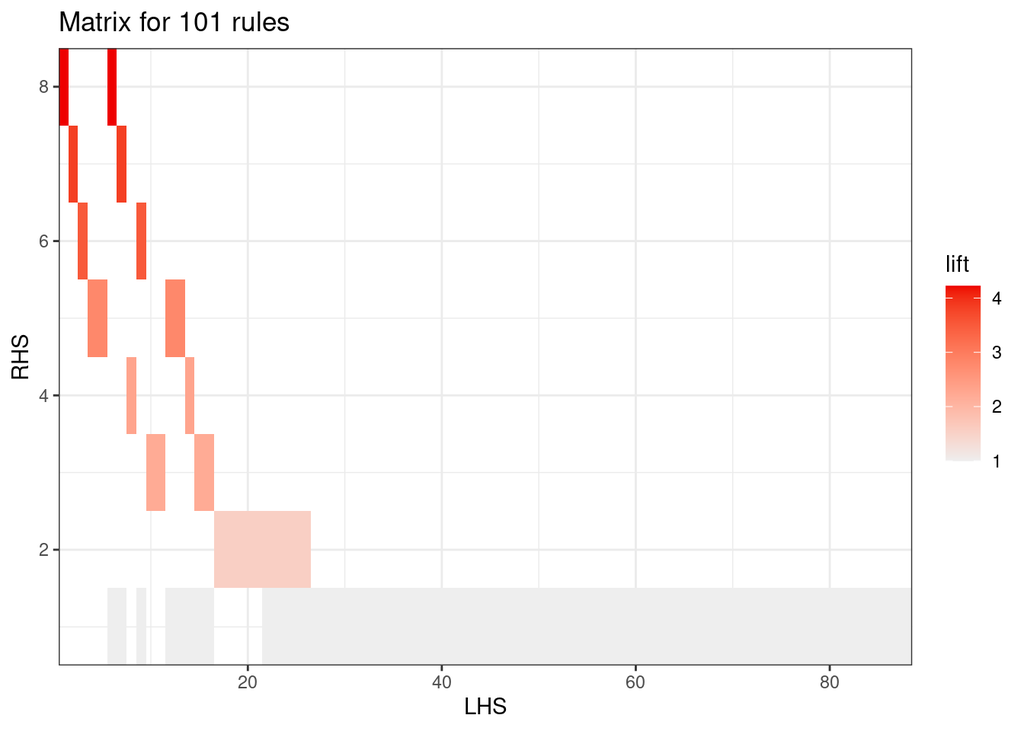

```r
plot(rules, method = "matrix", measure=c("support","confidence"))
```

### **ASSOCIATION MINING ANALYSIS**

**Here, association rules can be used to understand the prediction about which sides either home or away, are going to be more successful in future based on their current perdormances and result. Understanding the association or co-occurence will help us plan what promo or recommendation we will need to give to organizer based on their current outcomes. Network analysis help further help us find more insight compared to if only we look at the rules individually.**

### **CONCLUSION**

**More than 60% times, the home teams have won when they have scored goals >2, while the away teams have had draw or lost outcomes on the remaining part. Although the presented technique is not a sophisticated measure for establishing a general recommendation pattern in this dataset, it provides us with an underlying relationships between the teams and their goal differences. Such approach can also be incorporated in many activities, for instance in pitch analysis or a marketing campaign.**

———————————————————————–END———————————————————————–